# EDA2

### Import necessary Libraries

```python
import pandas as pd
import numpy as np
import seaborn as sns
import matplotlib.pyplot as plt
from sklearn.ensemble import IsolationForest
from sklearn.preprocessing import LabelEncoder
from sklearn.preprocessing import StandardScaler, MinMaxScaler
```

## Step1 :- Data Exploration and Preprocessing

#### Load the dataset

```python
df = pd.read_csv('/Users/jagdishreddy/Downloads/EDA2/adult_with_headers.csv')
```

```python
df.head()
```

|  | age | workclass | fnlwgt | education | education_num | marital_status | occupation | relationship | race | sex | capital_gain | capital_loss | hours_per_week | native_country | income |
| --- | --- | --- | --- | --- | --- | --- | --- | --- | --- | --- | --- | --- | --- | --- | --- |
| 0 | 39 | State-gov | 77516 | Bachelors | 13 | Never-married | Adm-clerical | Not-in-family | White | Male | 2174 | 0 | 40 | United-States | <=50K |
| 1 | 50 | Self-emp-not-inc | 83311 | Bachelors | 13 | Married-civ-spouse | Exec-managerial | Husband | White | Male | 0 | 0 | 13 | United-States | <=50K |
| 2 | 38 | Private | 215646 | HS-grad | 9 | Divorced | Handlers-cleaners | Not-in-family | White | Male | 0 | 0 | 40 | United-States | <=50K |
| 3 | 53 | Private | 234721 | 11th | 7 | Married-civ-spouse | Handlers-cleaners | Husband | Black | Male | 0 | 0 | 40 | United-States | <=50K |
| 4 | 28 | Private | 338409 | Bachelors | 13 | Married-civ-spouse | Prof-specialty | Wife | Black | Female | 0 | 0 | 40 | Cuba | <=50K |

```python
df.shape
```

```
(32561, 15)
```

```python
df.size
```

```
488415
```

#### Conduct basic data exploretion

```python
# summary statistics
df.describe()
```

|  | age | fnlwgt | education_num | capital_gain | capital_loss | hours_per_week |
| --- | --- | --- | --- | --- | --- | --- |
| count | 32561.000000 | 3.256100e+04 | 32561.000000 | 32561.000000 | 32561.000000 | 32561.000000 |
| mean | 38.581647 | 1.897784e+05 | 10.080679 | 1077.648844 | 87.303830 | 40.437456 |
| std | 13.640433 | 1.055500e+05 | 2.572720 | 7385.292085 | 402.960219 | 12.347429 |
| min | 17.000000 | 1.228500e+04 | 1.000000 | 0.000000 | 0.000000 | 1.000000 |
| 25% | 28.000000 | 1.178270e+05 | 9.000000 | 0.000000 | 0.000000 | 40.000000 |
| 50% | 37.000000 | 1.783560e+05 | 10.000000 | 0.000000 | 0.000000 | 40.000000 |
| 75% | 48.000000 | 2.370510e+05 | 12.000000 | 0.000000 | 0.000000 | 45.000000 |
| max | 90.000000 | 1.484705e+06 | 16.000000 | 99999.000000 | 4356.000000 | 99.000000 |

```python
# Data types
df.dtypes
```

```
age                int64
workclass         object
fnlwgt             int64
education         object
education_num      int64
marital_status    object
occupation        object
relationship      object
race              object
sex               object
capital_gain       int64
capital_loss       int64
hours_per_week     int64
native_country    object
income            object
dtype: object
```

```python
# Cheacking for null values
df.isnull().sum()
```

```
age               0
workclass         0
fnlwgt            0
education         0
education_num     0
marital_status    0
occupation        0
relationship      0
race              0
sex               0
capital_gain      0
capital_loss      0
hours_per_week    0
native_country    0
income            0
dtype: int64
```

## Step2 :- Handling missing values

--------- No Missing values ------------

## Step3 :- Applying Scaling Techniques to numerical Features

```python
from sklearn.preprocessing import StandardScaler,MinMaxScaler
```

```python
# Separating numerical and categorical features

numerical_features = ['age', 'fnlwgt', 'education_num', 'capital_gain', 'capital_loss', 'hours_per_week']
categorical_features = [col for col in df.columns if col not in numerical_features]
```

```python
standard_scaler = StandardScaler()
df_standard_scaled = df.copy()
df_standard_scaled[numerical_features] = standard_scaler.fit_transform(df[numerical_features])
```

```python
print("Standard Scaled Data:")
df_standard_scaled
```

```
Standard Scaled Data:
```

|  | age | workclass | fnlwgt | education | education_num | marital_status | occupation | relationship | race | sex | capital_gain | capital_loss | hours_per_week | native_country | income |
| --- | --- | --- | --- | --- | --- | --- | --- | --- | --- | --- | --- | --- | --- | --- | --- |
| 0 | 0.030671 | State-gov | -1.063611 | Bachelors | 1.134739 | Never-married | Adm-clerical | Not-in-family | White | Male | 0.148453 | -0.21666 | -0.035429 | United-States | <=50K |
| 1 | 0.837109 | Self-emp-not-inc | -1.008707 | Bachelors | 1.134739 | Married-civ-spouse | Exec-managerial | Husband | White | Male | -0.145920 | -0.21666 | -2.222153 | United-States | <=50K |
| 2 | -0.042642 | Private | 0.245079 | HS-grad | -0.420060 | Divorced | Handlers-cleaners | Not-in-family | White | Male | -0.145920 | -0.21666 | -0.035429 | United-States | <=50K |
| 3 | 1.057047 | Private | 0.425801 | 11th | -1.197459 | Married-civ-spouse | Handlers-cleaners | Husband | Black | Male | -0.145920 | -0.21666 | -0.035429 | United-States | <=50K |
| 4 | -0.775768 | Private | 1.408176 | Bachelors | 1.134739 | Married-civ-spouse | Prof-specialty | Wife | Black | Female | -0.145920 | -0.21666 | -0.035429 | Cuba | <=50K |
| ... | ... | ... | ... | ... | ... | ... | ... | ... | ... | ... | ... | ... | ... | ... | ... |
| 32556 | -0.849080 | Private | 0.639741 | Assoc-acdm | 0.746039 | Married-civ-spouse | Tech-support | Wife | White | Female | -0.145920 | -0.21666 | -0.197409 | United-States | <=50K |
| 32557 | 0.103983 | Private | -0.335433 | HS-grad | -0.420060 | Married-civ-spouse | Machine-op-inspct | Husband | White | Male | -0.145920 | -0.21666 | -0.035429 | United-States | >50K |
| 32558 | 1.423610 | Private | -0.358777 | HS-grad | -0.420060 | Widowed | Adm-clerical | Unmarried | White | Female | -0.145920 | -0.21666 | -0.035429 | United-States | <=50K |
| 32559 | -1.215643 | Private | 0.110960 | HS-grad | -0.420060 | Never-married | Adm-clerical | Own-child | White | Male | -0.145920 | -0.21666 | -1.655225 | United-States | <=50K |
| 32560 | 0.983734 | Self-emp-inc | 0.929893 | HS-grad | -0.420060 | Married-civ-spouse | Exec-managerial | Wife | White | Female | 1.888424 | -0.21666 | -0.035429 | United-States | >50K |

32561 rows × 15 columns

```python
Minmax_Scaler = MinMaxScaler()
df_minmax_scaled = df.copy()
df_minmax_scaled[numerical_features] = Minmax_Scaler.fit_transform(df[numerical_features])
```

```python
print("Minmax Scaled Data:")
df_minmax_scaled
```

```
Minmax Scaled Data:
```

|  | age | workclass | fnlwgt | education | education_num | marital_status | occupation | relationship | race | sex | capital_gain | capital_loss | hours_per_week | native_country | income |
| --- | --- | --- | --- | --- | --- | --- | --- | --- | --- | --- | --- | --- | --- | --- | --- |
| 0 | 0.301370 | State-gov | 0.044302 | Bachelors | 0.800000 | Never-married | Adm-clerical | Not-in-family | White | Male | 0.021740 | 0.0 | 0.397959 | United-States | <=50K |
| 1 | 0.452055 | Self-emp-not-inc | 0.048238 | Bachelors | 0.800000 | Married-civ-spouse | Exec-managerial | Husband | White | Male | 0.000000 | 0.0 | 0.122449 | United-States | <=50K |
| 2 | 0.287671 | Private | 0.138113 | HS-grad | 0.533333 | Divorced | Handlers-cleaners | Not-in-family | White | Male | 0.000000 | 0.0 | 0.397959 | United-States | <=50K |
| 3 | 0.493151 | Private | 0.151068 | 11th | 0.400000 | Married-civ-spouse | Handlers-cleaners | Husband | Black | Male | 0.000000 | 0.0 | 0.397959 | United-States | <=50K |
| 4 | 0.150685 | Private | 0.221488 | Bachelors | 0.800000 | Married-civ-spouse | Prof-specialty | Wife | Black | Female | 0.000000 | 0.0 | 0.397959 | Cuba | <=50K |
| ... | ... | ... | ... | ... | ... | ... | ... | ... | ... | ... | ... | ... | ... | ... | ... |
| 32556 | 0.136986 | Private | 0.166404 | Assoc-acdm | 0.733333 | Married-civ-spouse | Tech-support | Wife | White | Female | 0.000000 | 0.0 | 0.377551 | United-States | <=50K |
| 32557 | 0.315068 | Private | 0.096500 | HS-grad | 0.533333 | Married-civ-spouse | Machine-op-inspct | Husband | White | Male | 0.000000 | 0.0 | 0.397959 | United-States | >50K |
| 32558 | 0.561644 | Private | 0.094827 | HS-grad | 0.533333 | Widowed | Adm-clerical | Unmarried | White | Female | 0.000000 | 0.0 | 0.397959 | United-States | <=50K |
| 32559 | 0.068493 | Private | 0.128499 | HS-grad | 0.533333 | Never-married | Adm-clerical | Own-child | White | Male | 0.000000 | 0.0 | 0.193878 | United-States | <=50K |
| 32560 | 0.479452 | Self-emp-inc | 0.187203 | HS-grad | 0.533333 | Married-civ-spouse | Exec-managerial | Wife | White | Female | 0.150242 | 0.0 | 0.397959 | United-States | >50K |

32561 rows × 15 columns

### Discussion on Scenarios for Each Scaling Technique

#### Standard Scaling

-Preferred: When the data follows a Gaussian distribution or when using algorithms that assume data is normally distributed (e.g., linear regression, logistic regression, PCA). -Why: StandardScaler standardizes features by removing the mean and scaling to unit variance.

#### Min-Max Scaling

-Preferred: When the data does not follow a Gaussian distribution, or when using algorithms sensitive to the scale of the data (e.g., neural networks, k-nearest neighbors). -Why: MinMaxScaler scales features to a given range, typically [0, 1], ensuring all features contribute equally.

## Step4 :- Encoding techniques

#### One-Hot Encoding

-One-Hot Encoding is suitable for categorical variables with a small number of unique categories (less than 5 in this case).

#### Label Encoding

-Label Encoding is suitable for categorical variables with more than 5 unique categories.

```python
from sklearn.preprocessing import LabelEncoder,OneHotEncoder
```

```python
df['race'].unique()
```

```
array([' White', ' Black', ' Asian-Pac-Islander', ' Amer-Indian-Eskimo',
       ' Other'], dtype=object)
```

```python
df['sex'].unique()
```

```
array([' Male', ' Female'], dtype=object)
```

```python
df['workclass'].unique()
```

```
array([' State-gov', ' Self-emp-not-inc', ' Private', ' Federal-gov',
       ' Local-gov', ' ?', ' Self-emp-inc', ' Without-pay',
       ' Never-worked'], dtype=object)
```

```python
df['income'].unique()
```

```
array([' <=50K', ' >50K'], dtype=object)
```

```python
df['marital_status'].unique()
```

```
array([' Never-married', ' Married-civ-spouse', ' Divorced',
       ' Married-spouse-absent', ' Separated', ' Married-AF-spouse',
       ' Widowed'], dtype=object)
```

```python
df['relationship'].unique()
```

```
array([' Not-in-family', ' Husband', ' Wife', ' Own-child', ' Unmarried',
       ' Other-relative'], dtype=object)
```

```python
df['native_country'].unique()
```

```
array([' United-States', ' Cuba', ' Jamaica', ' India', ' ?', ' Mexico',
       ' South', ' Puerto-Rico', ' Honduras', ' England', ' Canada',
       ' Germany', ' Iran', ' Philippines', ' Italy', ' Poland',
       ' Columbia', ' Cambodia', ' Thailand', ' Ecuador', ' Laos',
       ' Taiwan', ' Haiti', ' Portugal', ' Dominican-Republic',
       ' El-Salvador', ' France', ' Guatemala', ' China', ' Japan',
       ' Yugoslavia', ' Peru', ' Outlying-US(Guam-USVI-etc)', ' Scotland',
       ' Trinadad&Tobago', ' Greece', ' Nicaragua', ' Vietnam', ' Hong',
       ' Ireland', ' Hungary', ' Holand-Netherlands'], dtype=object)
```

```python
df['education'].unique()
```

```
array([' Bachelors', ' HS-grad', ' 11th', ' Masters', ' 9th',
       ' Some-college', ' Assoc-acdm', ' Assoc-voc', ' 7th-8th',
       ' Doctorate', ' Prof-school', ' 5th-6th', ' 10th', ' 1st-4th',
       ' Preschool', ' 12th'], dtype=object)
```

```python
df['occupation'].unique()
```

```
array([' Adm-clerical', ' Exec-managerial', ' Handlers-cleaners',
       ' Prof-specialty', ' Other-service', ' Sales', ' Craft-repair',
       ' Transport-moving', ' Farming-fishing', ' Machine-op-inspct',
       ' Tech-support', ' ?', ' Protective-serv', ' Armed-Forces',
       ' Priv-house-serv'], dtype=object)
```

```python
categorical_cols_label = ['workclass', 'education', 'marital_status', 'occupation', 'relationship', 'native_country','race']
```

```python
categorical_cols_one_hot = ['sex', 'income']
```

##### Applying Label Encoded :-

```python
Label_encoder = LabelEncoder()
df['workclass'] = Label_encoder.fit_transform(df['workclass'])
df['education'] = Label_encoder.fit_transform(df['education'])
df['marital_status'] = Label_encoder.fit_transform(df['marital_status'])
df['occupation'] = Label_encoder.fit_transform(df['occupation'])
df['relationship'] = Label_encoder.fit_transform(df['relationship'])
df['native_country'] = Label_encoder.fit_transform(df['native_country'])
df['race'] = Label_encoder.fit_transform(df['race'])
```

```python
df
```

|  | age | workclass | fnlwgt | education | education_num | marital_status | occupation | relationship | race | sex | capital_gain | capital_loss | hours_per_week | native_country | income |
| --- | --- | --- | --- | --- | --- | --- | --- | --- | --- | --- | --- | --- | --- | --- | --- |
| 0 | 39 | 7 | 77516 | 9 | 13 | 4 | 1 | 1 | 4 | Male | 2174 | 0 | 40 | 39 | <=50K |
| 1 | 50 | 6 | 83311 | 9 | 13 | 2 | 4 | 0 | 4 | Male | 0 | 0 | 13 | 39 | <=50K |
| 2 | 38 | 4 | 215646 | 11 | 9 | 0 | 6 | 1 | 4 | Male | 0 | 0 | 40 | 39 | <=50K |
| 3 | 53 | 4 | 234721 | 1 | 7 | 2 | 6 | 0 | 2 | Male | 0 | 0 | 40 | 39 | <=50K |
| 4 | 28 | 4 | 338409 | 9 | 13 | 2 | 10 | 5 | 2 | Female | 0 | 0 | 40 | 5 | <=50K |
| ... | ... | ... | ... | ... | ... | ... | ... | ... | ... | ... | ... | ... | ... | ... | ... |
| 32556 | 27 | 4 | 257302 | 7 | 12 | 2 | 13 | 5 | 4 | Female | 0 | 0 | 38 | 39 | <=50K |
| 32557 | 40 | 4 | 154374 | 11 | 9 | 2 | 7 | 0 | 4 | Male | 0 | 0 | 40 | 39 | >50K |
| 32558 | 58 | 4 | 151910 | 11 | 9 | 6 | 1 | 4 | 4 | Female | 0 | 0 | 40 | 39 | <=50K |
| 32559 | 22 | 4 | 201490 | 11 | 9 | 4 | 1 | 3 | 4 | Male | 0 | 0 | 20 | 39 | <=50K |
| 32560 | 52 | 5 | 287927 | 11 | 9 | 2 | 4 | 5 | 4 | Female | 15024 | 0 | 40 | 39 | >50K |

32561 rows × 15 columns

##### Applyiny Onehot Encoded :-

```python
Onehot_encoder = OneHotEncoder(drop='first')
df_one_hot_encoded = df.copy()
df_one_hot_encoded = pd.get_dummies(df_one_hot_encoded, columns=categorical_cols_one_hot, drop_first=True)
```

```python
df_one_hot_encoded
```

|  | age | workclass | fnlwgt | education | education_num | marital_status | occupation | relationship | race | capital_gain | capital_loss | hours_per_week | native_country | sex_ Male | income_ >50K |
| --- | --- | --- | --- | --- | --- | --- | --- | --- | --- | --- | --- | --- | --- | --- | --- |
| 0 | 39 | 7 | 77516 | 9 | 13 | 4 | 1 | 1 | 4 | 2174 | 0 | 40 | 39 | 1 | 0 |
| 1 | 50 | 6 | 83311 | 9 | 13 | 2 | 4 | 0 | 4 | 0 | 0 | 13 | 39 | 1 | 0 |
| 2 | 38 | 4 | 215646 | 11 | 9 | 0 | 6 | 1 | 4 | 0 | 0 | 40 | 39 | 1 | 0 |
| 3 | 53 | 4 | 234721 | 1 | 7 | 2 | 6 | 0 | 2 | 0 | 0 | 40 | 39 | 1 | 0 |
| 4 | 28 | 4 | 338409 | 9 | 13 | 2 | 10 | 5 | 2 | 0 | 0 | 40 | 5 | 0 | 0 |
| ... | ... | ... | ... | ... | ... | ... | ... | ... | ... | ... | ... | ... | ... | ... | ... |
| 32556 | 27 | 4 | 257302 | 7 | 12 | 2 | 13 | 5 | 4 | 0 | 0 | 38 | 39 | 0 | 0 |
| 32557 | 40 | 4 | 154374 | 11 | 9 | 2 | 7 | 0 | 4 | 0 | 0 | 40 | 39 | 1 | 1 |
| 32558 | 58 | 4 | 151910 | 11 | 9 | 6 | 1 | 4 | 4 | 0 | 0 | 40 | 39 | 0 | 0 |
| 32559 | 22 | 4 | 201490 | 11 | 9 | 4 | 1 | 3 | 4 | 0 | 0 | 20 | 39 | 1 | 0 |
| 32560 | 52 | 5 | 287927 | 11 | 9 | 2 | 4 | 5 | 4 | 15024 | 0 | 40 | 39 | 0 | 1 |

32561 rows × 15 columns

```python
df_label_encoded = df_one_hot_encoded.copy()
```

```python
print('Label and One-Hot Encoded Data :')
df_label_encoded
```

```
Label and One-Hot Encoded Data :
```

|  | age | workclass | fnlwgt | education | education_num | marital_status | occupation | relationship | race | capital_gain | capital_loss | hours_per_week | native_country | sex_ Male | income_ >50K |
| --- | --- | --- | --- | --- | --- | --- | --- | --- | --- | --- | --- | --- | --- | --- | --- |
| 0 | 39 | 7 | 77516 | 9 | 13 | 4 | 1 | 1 | 4 | 2174 | 0 | 40 | 39 | 1 | 0 |
| 1 | 50 | 6 | 83311 | 9 | 13 | 2 | 4 | 0 | 4 | 0 | 0 | 13 | 39 | 1 | 0 |
| 2 | 38 | 4 | 215646 | 11 | 9 | 0 | 6 | 1 | 4 | 0 | 0 | 40 | 39 | 1 | 0 |
| 3 | 53 | 4 | 234721 | 1 | 7 | 2 | 6 | 0 | 2 | 0 | 0 | 40 | 39 | 1 | 0 |
| 4 | 28 | 4 | 338409 | 9 | 13 | 2 | 10 | 5 | 2 | 0 | 0 | 40 | 5 | 0 | 0 |
| ... | ... | ... | ... | ... | ... | ... | ... | ... | ... | ... | ... | ... | ... | ... | ... |
| 32556 | 27 | 4 | 257302 | 7 | 12 | 2 | 13 | 5 | 4 | 0 | 0 | 38 | 39 | 0 | 0 |
| 32557 | 40 | 4 | 154374 | 11 | 9 | 2 | 7 | 0 | 4 | 0 | 0 | 40 | 39 | 1 | 1 |
| 32558 | 58 | 4 | 151910 | 11 | 9 | 6 | 1 | 4 | 4 | 0 | 0 | 40 | 39 | 0 | 0 |
| 32559 | 22 | 4 | 201490 | 11 | 9 | 4 | 1 | 3 | 4 | 0 | 0 | 20 | 39 | 1 | 0 |
| 32560 | 52 | 5 | 287927 | 11 | 9 | 2 | 4 | 5 | 4 | 15024 | 0 | 40 | 39 | 0 | 1 |

32561 rows × 15 columns

## Pros and Cons of One-Hot Encoding and Label Encoding

#### One-Hot Encoding

Pros:

1.Does not assume any ordinal relationship between categories.

2.Suitable for categorical variables with no intrinsic order.

Cons:

1.Can lead to a high-dimensional feature space if there are many unique categories, resulting in the "curse of dimensionality."

2.May increase the complexity and computational cost of the model.

#### Label Encoding

Pros:

1.Simpler and more efficient for algorithms that can handle categorical data natively.

2.Avoids the issue of high dimensionality.

Cons:

1.Imposes an arbitrary ordinal relationship between categories, which might not be meaningful.

2.Can cause problems for algorithms that assume ordinality (e.g., linear models), as they might interpret the encoded values as having a ranking.

## Step5 :- Feature Engineering

```python
df.columns
```

```
Index(['age', 'workclass', 'fnlwgt', 'education', 'education_num',
       'marital_status', 'occupation', 'relationship', 'race', 'sex',
       'capital_gain', 'capital_loss', 'hours_per_week', 'native_country',
       'income'],
      dtype='object')
```

```python
# Create new features
df['age_hours_per_week'] = df['age'] * df['hours_per_week']
df['education_num_over_hours_per_week'] = df['education_num'] / df['hours_per_week']
```

```python
# Log transformation of a skewed feature
df['capital_gain_log'] = np.log1p(df['capital_gain'])
```

```python
df
```

|  | age | workclass | fnlwgt | education | education_num | marital_status | occupation | relationship | race | sex | capital_gain | capital_loss | hours_per_week | native_country | income | age_hours_per_week | education_num_over_hours_per_week | capital_gain_log |
| --- | --- | --- | --- | --- | --- | --- | --- | --- | --- | --- | --- | --- | --- | --- | --- | --- | --- | --- |
| 0 | 39 | 7 | 77516 | 9 | 13 | 4 | 1 | 1 | 4 | Male | 2174 | 0 | 40 | 39 | <=50K | 1560 | 0.325000 | 7.684784 |
| 1 | 50 | 6 | 83311 | 9 | 13 | 2 | 4 | 0 | 4 | Male | 0 | 0 | 13 | 39 | <=50K | 650 | 1.000000 | 0.000000 |
| 2 | 38 | 4 | 215646 | 11 | 9 | 0 | 6 | 1 | 4 | Male | 0 | 0 | 40 | 39 | <=50K | 1520 | 0.225000 | 0.000000 |
| 3 | 53 | 4 | 234721 | 1 | 7 | 2 | 6 | 0 | 2 | Male | 0 | 0 | 40 | 39 | <=50K | 2120 | 0.175000 | 0.000000 |
| 4 | 28 | 4 | 338409 | 9 | 13 | 2 | 10 | 5 | 2 | Female | 0 | 0 | 40 | 5 | <=50K | 1120 | 0.325000 | 0.000000 |
| ... | ... | ... | ... | ... | ... | ... | ... | ... | ... | ... | ... | ... | ... | ... | ... | ... | ... | ... |
| 32556 | 27 | 4 | 257302 | 7 | 12 | 2 | 13 | 5 | 4 | Female | 0 | 0 | 38 | 39 | <=50K | 1026 | 0.315789 | 0.000000 |
| 32557 | 40 | 4 | 154374 | 11 | 9 | 2 | 7 | 0 | 4 | Male | 0 | 0 | 40 | 39 | >50K | 1600 | 0.225000 | 0.000000 |
| 32558 | 58 | 4 | 151910 | 11 | 9 | 6 | 1 | 4 | 4 | Female | 0 | 0 | 40 | 39 | <=50K | 2320 | 0.225000 | 0.000000 |
| 32559 | 22 | 4 | 201490 | 11 | 9 | 4 | 1 | 3 | 4 | Male | 0 | 0 | 20 | 39 | <=50K | 440 | 0.450000 | 0.000000 |
| 32560 | 52 | 5 | 287927 | 11 | 9 | 2 | 4 | 5 | 4 | Female | 15024 | 0 | 40 | 39 | >50K | 2080 | 0.225000 | 9.617471 |

32561 rows × 18 columns

## Step6 :- Feature Selection

#### Calculate the PPS matrix

Computes the Predictive Power Score (PPS) matrix to understand feature relationships.

```python
import ppscore as pps
```

```python
pps_matrix = pps.matrix(df)
```

```python
pps_matrix
```

|  | x | y | ppscore | case | is_valid_score | metric | baseline_score | model_score | model |
| --- | --- | --- | --- | --- | --- | --- | --- | --- | --- |
| 0 | age | age | 1.000000 | predict_itself | True | None | 0.000000 | 1.000000 | None |
| 1 | age | workclass | 0.000000 | regression | True | mean absolute error | 0.742600 | 0.875681 | DecisionTreeRegressor() |
| 2 | age | fnlwgt | 0.000000 | regression | True | mean absolute error | 75872.186200 | 77535.141544 | DecisionTreeRegressor() |
| 3 | age | education | 0.000000 | regression | True | mean absolute error | 2.759000 | 2.806164 | DecisionTreeRegressor() |
| 4 | age | education_num | 0.000000 | regression | True | mean absolute error | 1.853000 | 1.898306 | DecisionTreeRegressor() |
| ... | ... | ... | ... | ... | ... | ... | ... | ... | ... |
| 319 | capital_gain_log | native_country | 0.000000 | regression | True | mean absolute error | 2.374800 | 4.234430 | DecisionTreeRegressor() |
| 320 | capital_gain_log | income | 0.297578 | classification | True | weighted F1 | 0.653115 | 0.756341 | DecisionTreeClassifier() |
| 321 | capital_gain_log | age_hours_per_week | 0.007133 | regression | True | mean absolute error | 580.791000 | 576.648421 | DecisionTreeRegressor() |
| 322 | capital_gain_log | education_num_over_hours_per_week | 0.000000 | regression | True | mean absolute error | 0.103804 | 0.118667 | DecisionTreeRegressor() |
| 323 | capital_gain_log | capital_gain_log | 1.000000 | predict_itself | True | None | 0.000000 | 1.000000 | None |

324 rows × 9 columns

```python
pps_matrix.corr()
```

|  | ppscore | is_valid_score | baseline_score | model_score |
| --- | --- | --- | --- | --- |
| ppscore | 1.000000 | NaN | -0.089836 | -0.091631 |
| is_valid_score | NaN | NaN | NaN | NaN |
| baseline_score | -0.089836 | NaN | 1.000000 | 0.999651 |
| model_score | -0.091631 | NaN | 0.999651 | 1.000000 |

## Compare with correlation matrix

```python
corr_matrix = df.corr()
```

```python
corr_matrix
```

|  | age | workclass | fnlwgt | education | education_num | marital_status | occupation | relationship | race | capital_gain | capital_loss | hours_per_week | native_country | age_hours_per_week | education_num_over_hours_per_week | capital_gain_log |
| --- | --- | --- | --- | --- | --- | --- | --- | --- | --- | --- | --- | --- | --- | --- | --- | --- |
| age | 1.000000 | 0.003787 | -0.076646 | -0.010508 | 0.036527 | -0.266288 | -0.020947 | -0.263698 | 0.028718 | 0.077674 | 0.057775 | 0.068756 | -0.001151 | 0.700467 | 0.055820 | 0.124183 |
| workclass | 0.003787 | 1.000000 | -0.016656 | 0.023513 | 0.052085 | -0.064731 | 0.254892 | -0.090461 | 0.049742 | 0.033835 | 0.012216 | 0.138962 | -0.007690 | 0.109813 | -0.086428 | 0.022672 |
| fnlwgt | -0.076646 | -0.016656 | 1.000000 | -0.028145 | -0.043195 | 0.028153 | 0.001597 | 0.008931 | -0.021291 | 0.000432 | -0.010252 | -0.018768 | -0.051966 | -0.069565 | -0.012346 | -0.004414 |
| education | -0.010508 | 0.023513 | -0.028145 | 1.000000 | 0.359153 | -0.038407 | -0.021260 | -0.010876 | 0.014131 | 0.030046 | 0.016746 | 0.055510 | 0.064288 | 0.024049 | 0.056573 | 0.024955 |
| education_num | 0.036527 | 0.052085 | -0.043195 | 0.359153 | 1.000000 | -0.069304 | 0.109697 | -0.094153 | 0.031838 | 0.122630 | 0.079923 | 0.148123 | 0.050840 | 0.121482 | 0.165014 | 0.129135 |
| marital_status | -0.266288 | -0.064731 | 0.028153 | -0.038407 | -0.069304 | 1.000000 | -0.009654 | 0.185451 | -0.068013 | -0.043393 | -0.034187 | -0.190519 | -0.023819 | -0.307991 | 0.070218 | -0.066595 |
| occupation | -0.020947 | 0.254892 | 0.001597 | -0.021260 | 0.109697 | -0.009654 | 1.000000 | -0.075607 | 0.006763 | 0.025505 | 0.017987 | 0.080383 | -0.012543 | 0.050422 | -0.039803 | 0.019852 |
| relationship | -0.263698 | -0.090461 | 0.008931 | -0.010876 | -0.094153 | 0.185451 | -0.075607 | 1.000000 | -0.116055 | -0.057919 | -0.061062 | -0.248974 | -0.005507 | -0.327142 | 0.072011 | -0.083402 |
| race | 0.028718 | 0.049742 | -0.021291 | 0.014131 | 0.031838 | -0.068013 | 0.006763 | -0.116055 | 1.000000 | 0.011145 | 0.018899 | 0.041910 | 0.137852 | 0.047061 | 0.003134 | 0.024089 |
| capital_gain | 0.077674 | 0.033835 | 0.000432 | 0.030046 | 0.122630 | -0.043393 | 0.025505 | -0.057919 | 0.011145 | 1.000000 | -0.031615 | 0.078409 | -0.001982 | 0.112552 | -0.003269 | 0.564520 |
| capital_loss | 0.057775 | 0.012216 | -0.010252 | 0.016746 | 0.079923 | -0.034187 | 0.017987 | -0.061062 | 0.018899 | -0.031615 | 1.000000 | 0.054256 | 0.000419 | 0.079690 | -0.001971 | -0.064840 |
| hours_per_week | 0.068756 | 0.138962 | -0.018768 | 0.055510 | 0.148123 | -0.190519 | 0.080383 | -0.248974 | 0.041910 | 0.078409 | 0.054256 | 1.000000 | -0.002671 | 0.710038 | -0.454538 | 0.083821 |
| native_country | -0.001151 | -0.007690 | -0.051966 | 0.064288 | 0.050840 | -0.023819 | -0.012543 | -0.005507 | 0.137852 | -0.001982 | 0.000419 | -0.002671 | 1.000000 | -0.000339 | 0.011509 | 0.005701 |
| age_hours_per_week | 0.700467 | 0.109813 | -0.069565 | 0.024049 | 0.121482 | -0.307991 | 0.050422 | -0.327142 | 0.047061 | 0.112552 | 0.079690 | 0.710038 | -0.000339 | 1.000000 | -0.300364 | 0.143710 |
| education_num_over_hours_per_week | 0.055820 | -0.086428 | -0.012346 | 0.056573 | 0.165014 | 0.070218 | -0.039803 | 0.072011 | 0.003134 | -0.003269 | -0.001971 | -0.454538 | 0.011509 | -0.300364 | 1.000000 | -0.002580 |
| capital_gain_log | 0.124183 | 0.022672 | -0.004414 | 0.024955 | 0.129135 | -0.066595 | 0.019852 | -0.083402 | 0.024089 | 0.564520 | -0.064840 | 0.083821 | 0.005701 | 0.143710 | -0.002580 | 1.000000 |

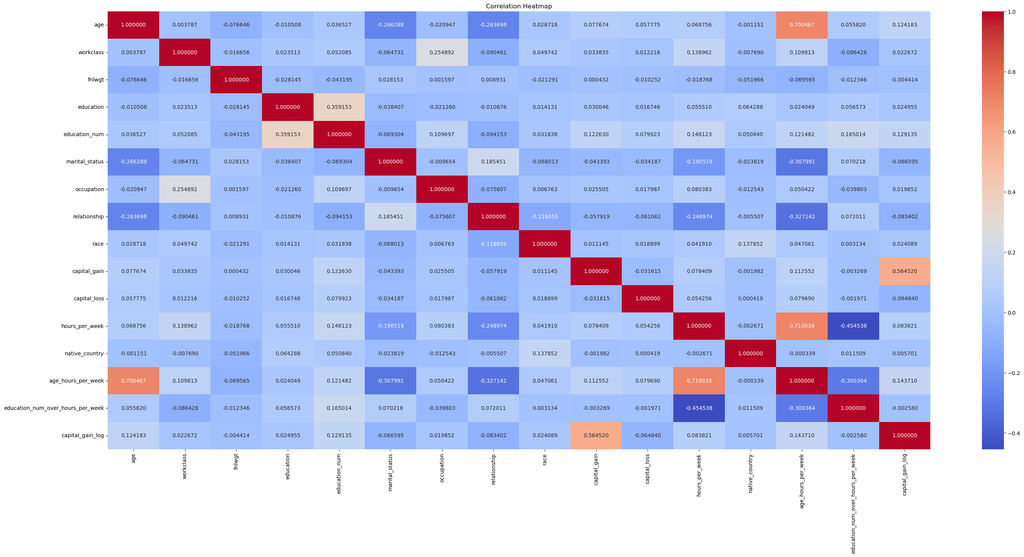

```python
plt.figure(figsize=(35,15))
sns.heatmap(corr_matrix,annot=True,cmap='coolwarm',fmt='2f')
plt.title("Correlation Heatmap")
plt.show()
```